# Preliminary Analysis: GSE295191

Author

ZB3101 CA2

Published

April 24, 2026

# Import packages

```r
library(GEOquery)
library(dplyr)
library(knitr)
library(kableExtra)
library(ggplot2)
library(tidyr)
library(stringr)
# BiocManager::install('GEOquery')
```

# Check that both FASTQ samples are present

```r
files <- list.files("data", pattern = "^(SRR33191495|SRR33191498).*\\.fastq$")

if (length(files) != 4) {
  stop("Required files are missing in data/")
} else {
  print(files)
  print("required files are present")
}
```

```
[1] "SRR33191495_1.fastq" "SRR33191495_2.fastq" "SRR33191498_1.fastq"
[4] "SRR33191498_2.fastq"
[1] "required files are present"
```

# Pull metadata from GEO

```r
# get metadata from GEO
gse   <- getGEO("GSE295191", GSEMatrix = TRUE, getGPL = FALSE)
pheno <- pData(phenoData(gse[[1]]))

# Clean up condition / replicate information for a readable table
meta_clean <- pheno |>
  mutate(
    Condition = case_when(
      str_detect(title, regex("dmso",      ignore_case = TRUE)) ~ "DMSO (Control)",
      str_detect(title, regex("ponatinib", ignore_case = TRUE)) ~ "Ponatinib 10 nM",
      TRUE ~ NA_character_
    ),
    Replicate = str_extract(title, "\\d+$")
  ) |>
  select(geo_accession, title, source_name_ch1, Condition, Replicate) |>
  rename(
    `GEO Accession` = geo_accession,
    `Sample Title`  = title,
    `Source`        = source_name_ch1
  )

# Display cleaned metadata
meta_clean |>
  kable(align = "llllc") |>
  kable_styling(bootstrap_options = c("striped", "hover", "condensed"),
                full_width = FALSE) |>
  column_spec(4, bold = TRUE,
              color = ifelse(meta_clean$Condition == "DMSO (Control)",
                             "#1a6faf", "#a63603"))
```

|  | GEO Accession | Sample Title | Source | Condition | Replicate |
| --- | --- | --- | --- | --- | --- |
| GSM8943432 | GSM8943432 | mouse, CD8, DMSO_1 | splenocytes | DMSO (Control) | 1 |
| GSM8943433 | GSM8943433 | mouse, CD8, DMSO_2 | splenocytes | DMSO (Control) | 2 |
| GSM8943434 | GSM8943434 | mouse, CD8, DMSO_3 | splenocytes | DMSO (Control) | 3 |
| GSM8943435 | GSM8943435 | mouse, CD8, ponatinib_1 | splenocytes | Ponatinib 10 nM | 1 |
| GSM8943436 | GSM8943436 | mouse, CD8, ponatinib_2 | splenocytes | Ponatinib 10 nM | 2 |
| GSM8943437 | GSM8943437 | mouse, CD8, ponatinib_3 | splenocytes | Ponatinib 10 nM | 3 |

# Quality Control with FastQC

## 2.1 Sample selection

Two samples (one per condition) were selected for preliminary QC:

```r
qc_samples <- tibble(
  `SRA Run`   = c("SRR33191495", "SRR33191498"),
  Condition   = c("DMSO (Control)", "Ponatinib 10 nM"),
  `Read 1`    = c("SRR33191495_1.fastq", "SRR33191498_1.fastq"),
  `Read 2`    = c("SRR33191495_2.fastq", "SRR33191498_2.fastq")
)

qc_samples |>
  kable(align = "llll") |>
  kable_styling(bootstrap_options = c("striped", "hover", "condensed"),
                full_width = FALSE)
```

| SRA Run | Condition | Read 1 | Read 2 |
| --- | --- | --- | --- |
| SRR33191495 | DMSO (Control) | SRR33191495_1.fastq | SRR33191495_2.fastq |
| SRR33191498 | Ponatinib 10 nM | SRR33191498_1.fastq | SRR33191498_2.fastq |

## 2.2 Run FastQC

FastQC is run on both mates (R1 + R2) of each sample. Results are written to `results/fastqc/` and the per-sample zip archives are unpacked so that the PNG figures can be embedded below.

```bash
mkdir -p results/fastqc
fastqc data/*.fastq* -o results/fastqc
```

```r
fastqc_dir <- "results/fastqc"

if (dir.exists(fastqc_dir)) {
  zips <- list.files(fastqc_dir, pattern = "_fastqc\\.zip$", full.names = TRUE)
  for (z in zips) {
    out_dir <- sub("\\.zip$", "", z)
    if (!dir.exists(out_dir)) unzip(z, exdir = fastqc_dir)
  }
}
```

## 2.3 FastQC summary across the two samples

```r
summary_files <- list.files(
  "results/fastqc", pattern = "summary\\.txt$",
  recursive = TRUE, full.names = TRUE
)

if (length(summary_files) > 0) {
  summaries <- lapply(summary_files, function(f) {
    df <- read.delim(f, header = FALSE,
                     col.names = c("Status", "Module", "File"))
    df$Sample <- sub("_fastqc.*", "", basename(f))
    df
  }) |> bind_rows()

  summaries |>
    select(Sample, Module, Status) |>
    pivot_wider(names_from = Sample, values_from = Status) |>
    kable(align = "lll") |>
    kable_styling(bootstrap_options = c("striped", "hover", "condensed"),
                  full_width = FALSE)
} else {
  cat("*FastQC summary will appear here after the FastQC bash chunk is run.*")
}
```

[output not shown]

## 2.4 DMSO control — SRR33191495 (Read 1)

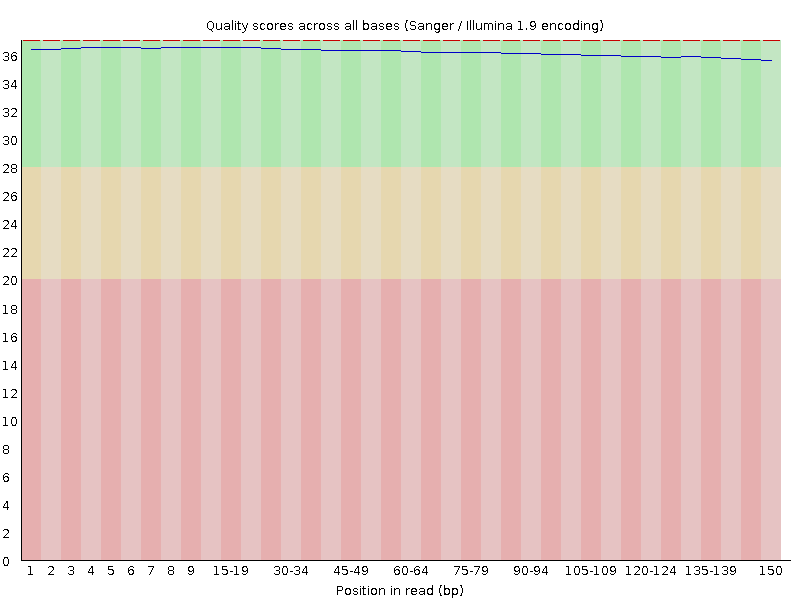

Figure 1: Per-base sequence quality — DMSO (SRR33191495_1).

```r
img <- "results/fastqc/SRR33191495_1_fastqc/Images/per_base_quality.png"
if (file.exists(img)) knitr::include_graphics(img) else
  cat("*Figure appears here after FastQC is executed.*")
```

Phred stays around 37 from 1 to 150 position. No big 3’ decay.

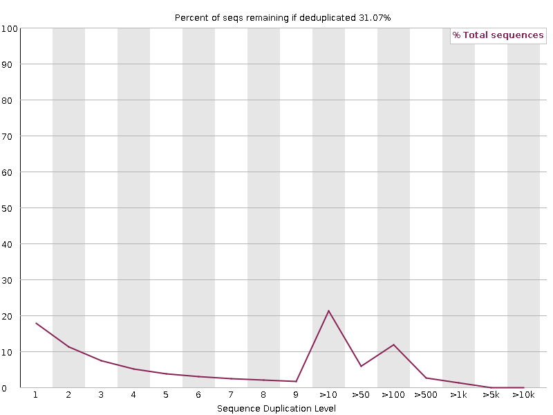

Figure 2: Sequence duplication levels — DMSO (SRR33191495_1).

```r
img <- "results/fastqc/SRR33191495_1_fastqc/Images/duplication_levels.png"
if (file.exists(img)) knitr::include_graphics(img) else
  cat("*Figure appears here after FastQC is executed.*")
```

Observed duplication rate of around 69%, so only 31% is unique. 2 bumps at >10 and >100 bins. Both the shape and duplication rate are expected for RNA-Seq of CD8+ cells, where a few transcripts dominate the library.

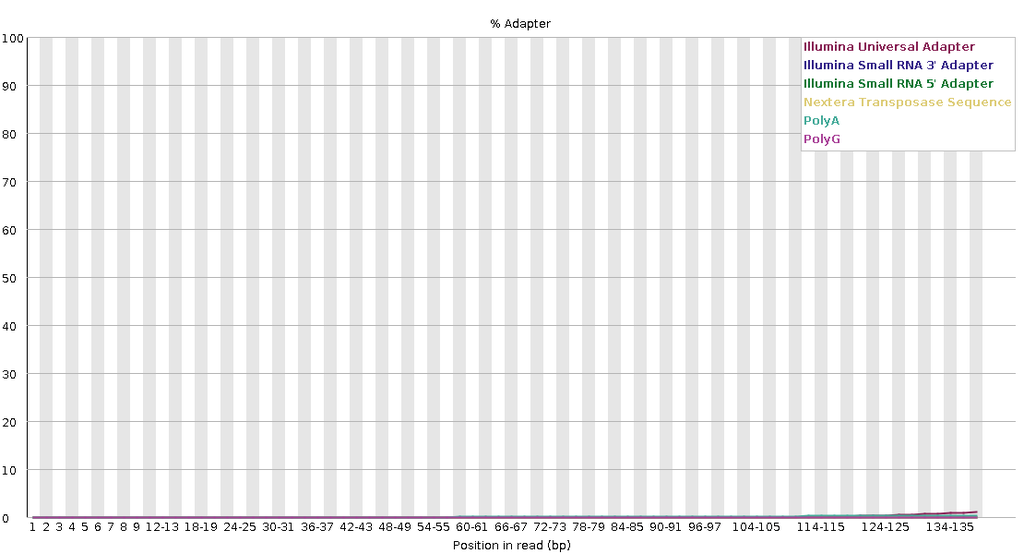

Figure 3: Adapter content — DMSO (SRR33191495_1).

```r
img <- "results/fastqc/SRR33191495_1_fastqc/Images/adapter_content.png"
if (file.exists(img)) knitr::include_graphics(img) else
  cat("*Figure appears here after FastQC is executed.*")
```

## 2.5 Ponatinib — SRR33191498 (Read 1)

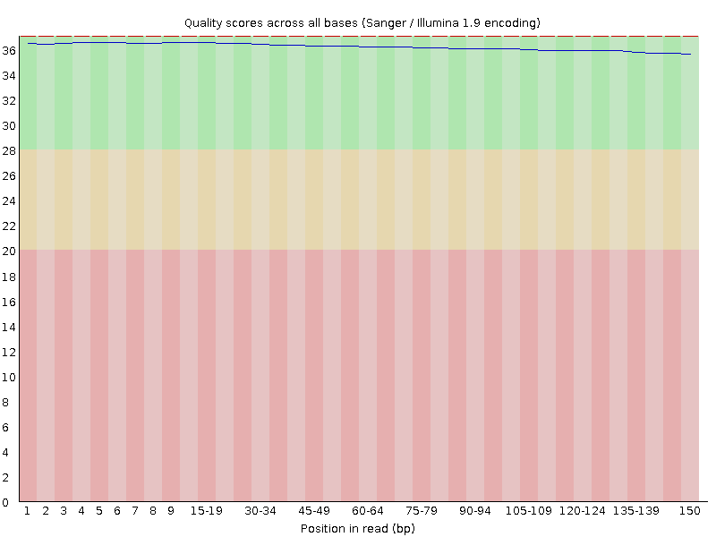

Figure 4: Per-base sequence quality — Ponatinib (SRR33191498_1).

```r
img <- "results/fastqc/SRR33191498_1_fastqc/Images/per_base_quality.png"
if (file.exists(img)) knitr::include_graphics(img) else
  cat("*Figure appears here after FastQC is executed.*")
```

Phred stays around 37 from 1 to 150 position. No big 3’ decay. Almost identical to DMSO.

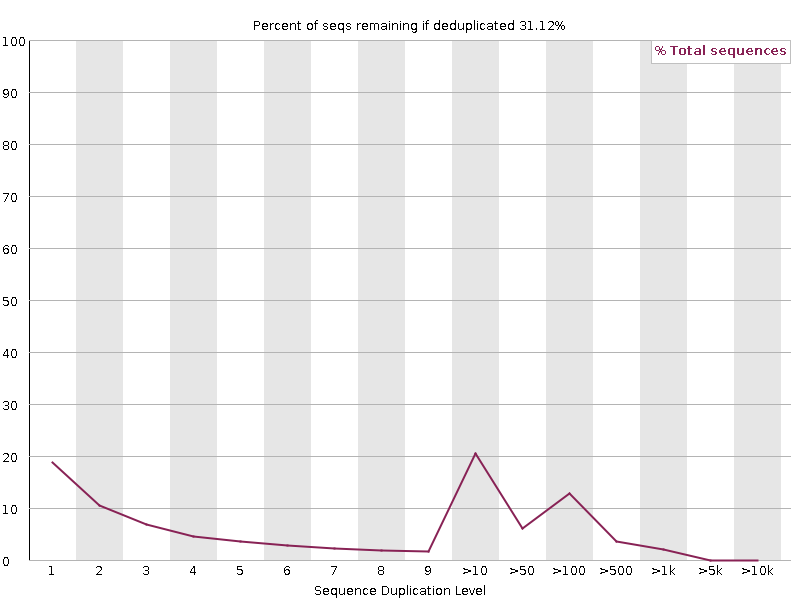

Figure 5: Sequence duplication levels — Ponatinib (SRR33191498_1).

```r
img <- "results/fastqc/SRR33191498_1_fastqc/Images/duplication_levels.png"
if (file.exists(img)) knitr::include_graphics(img) else
  cat("*Figure appears here after FastQC is executed.*")
```

Observed duplication rate of around 69%, so only 31% is unique. This might be expected for RNA-Seq, where a few genes dominate expression. Graph is similar to DMSO.

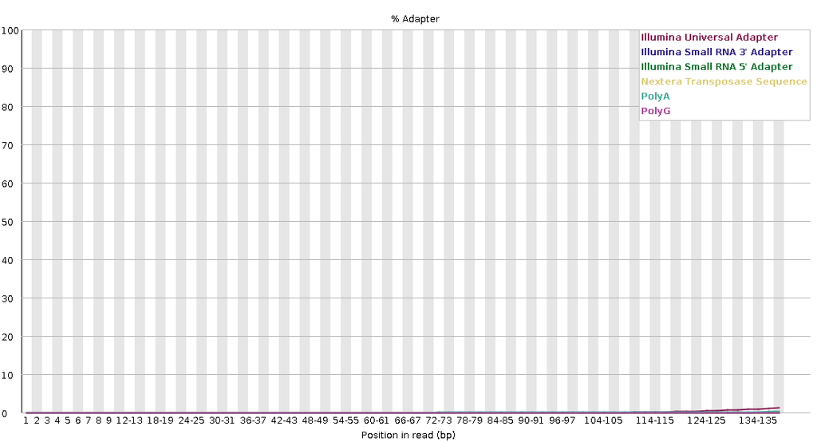

Figure 6: Adapter content — Ponatinib (SRR33191498_1).

```r
img <- "results/fastqc/SRR33191498_1_fastqc/Images/adapter_content.png"
if (file.exists(img)) knitr::include_graphics(img) else
  cat("*Figure appears here after FastQC is executed.*")
```

## 2.6 Interpretations

### Per-base sequence quality

For both samples, Phred stays around 37 from 1 to 150 position, well above 30 threshold. Slight 3’ decay. No trimming necessary.

### Sequence duplication

Observed duplication rate of around 69%, so only 31% is unique. 2 bumps at >10 and >100 bins. Both the shape and duplication rate are expected for RNA-Seq of CD8+ cells, where a few transcripts dominate the library. However duplication rate is higher than expected for activated CD8+ cells (20-40%). Both graphs near-identical.

### Adapter content

For both samples, all adapter traces well below 5% threshold, minimal adapter trimming needed.

### Consequences for the analysis pipeline

No need to remove duplicates since this is RNA-seq and deduplicating can lead to loss of signal, instead use Kallisto or UMI-tools downstream since they can handle multi-mapping.

No need to trim with cut_tail. Can still trim with fastp –detect_adapter_for_pe since detection is cheap.

Both samples can proceed to STAR alignment step.